# Anime_KNN_Research_Project

### Executive Summary:

A style of animation originating from Japan, "Anime" has become increasingly popular in the West in the past couple decades. The purpose of this memo is to perform an exploratory data analysis of an anime dataset to find compelling relationships between the variables and to create a model using KNN to see how accurately it can predict the similarities in popularity (overall rating) of different anime based on genre, source material, and number of members (people who are interested in it, not necessarily watching it currently) following the anime.

Below are the questions I chose to answer for my exploratory analysis:

- outliers, missing values, descriptive stats
- Top rated animes
- Anime with most eps
- Anime rating trends over time
- Top animes based on membership following
- Top genres based on rating
- genres with the most animes tagged to it
- relationship between source material and rating

I created two models (regression and classification) for this dataset to compare the accuracy. I chose the member total, source material, and genre as predictors based on the assumption of that these factors would be the strongest indicators for similarities in popularity. I considered episode total as a predictor, but my analysis showed that volume of episodes is not necessarily a good indicator of similarities in popularity. “Oyako Club”, which is a kid’s anime, has almost 1800 episodes but does not crack the top 20 in terms of overall rating. The classification model proved to be more accurate by ~10%. To increase accuracy for either model, more data would need to be added to this dataset to offset curse of dimensionality.

#### Feature Engineering:

- dropped rows with a zero rating
- created dummies for source material for KNN algorithm
- 'year' based on anime air date

#### Data Dictionary:

- anime_id - identifier for anime title
- anime_name - title of the anime
- studio_id - identifier for studio that created the anime
- studio_name - name of studio
- episodes_total - total number of episodes for the anime
- source_material - source from which the anime originated before adapted into a TV show. Originals, Manga, Video game, book, light novel, etc.
- air_date - date the anime started running
- overall_rating - rating given to the anime based on viewers feedback
- members - number of people following the title (not necessarily watching it)
- synopsis - plot of the anime
- number of tags - number of genres that are tagged to the anime
- Genres:
  - 'Action', 'Adventure', 'Cars', 'Comedy', 'Dementia', 'Demons', 'Drama', 'Ecchi', 'Fantasy', 'Game', 'Harem', 'Hentai', 'Historical', 'Horror', 'Josei', 'Kids', 'Magic', 'Martial_Arts', 'Mecha', 'Military', 'Music', 'Mystery', 'Parody', 'Police', 'Psychological', 'Romance', 'Samurai', 'School', 'Sci-Fi', 'Seinen', 'Shoujo', 'Shoujo_Ai', 'Shounen', 'Shounen_Ai', 'Slice_of_Life', 'Space', 'Sports', 'Super_Power', 'Supernatural', 'Thriller', 'Vampire', 'Yaoi', 'Yuri'
  - The above genres are indicated by 0 or 1. 0 = anime is not associated with this genre, 1 = anime is associated with this genre!

### Exploratory Analysis

```python
import pandas as pd
import numpy as np
np.warnings.filterwarnings('ignore')

df = pd.read_csv('/Users/drewmcknight1/Desktop/MISY630/My Materials/Animes.csv')
df.head()
```

|  | Unnamed: 0 | anime_id | anime_name | studio_id | episodes_total | source_material | air_date | overall_rating | members | synopsis | ... | Slice_of_Life | Space | Sports | Super_Power | Supernatural | Thriller | Vampire | Yaoi | Yuri | studio_name |
| --- | --- | --- | --- | --- | --- | --- | --- | --- | --- | --- | --- | --- | --- | --- | --- | --- | --- | --- | --- | --- | --- |
| 0 | 0 | 1 | Cowboy Bebop | 14 | 26.0 | Original | Apr 3, 1998, 01:00 | 8.79 | 983565 | In the year 2071, humanity has colonized sever... | ... | 0.0 | 1.0 | 0.0 | 0.0 | 0.0 | 0.0 | 0.0 | 0.0 | 0.0 | Sunrise |
| 1 | 1 | 7 | Witch Hunter Robin | 14 | 26.0 | Original | Jul 2, 2002 | 7.29 | 87048 | Witches are individuals with special powers li... | ... | 0.0 | 0.0 | 0.0 | 0.0 | 1.0 | 0.0 | 0.0 | 0.0 | 0.0 | Sunrise |
| 2 | 2 | 28 | Yakitate!! Japan | 14 | 69.0 | Manga | Oct 12, 2004 | 7.98 | 72329 | Yakitate means "fresh baked", but the word "Ja... | ... | 0.0 | 0.0 | 0.0 | 0.0 | 0.0 | 0.0 | 0.0 | 0.0 | 0.0 | Sunrise |
| 3 | 3 | 69 | Cluster Edge | 14 | 25.0 | Original | Oct 5, 2005, 01:00 | 6.40 | 8623 | Cluster Edge Academy isn't just any school; it... | ... | 0.0 | 0.0 | 0.0 | 0.0 | 0.0 | 0.0 | 0.0 | 0.0 | 0.0 | Sunrise |
| 4 | 4 | 80 | Mobile Suit Gundam | 14 | 43.0 | Original | Apr 7, 1979, 17:30 | 7.81 | 84070 | It is year 0079 of the Universal Century. Mank... | ... | 0.0 | 1.0 | 0.0 | 0.0 | 0.0 | 0.0 | 0.0 | 0.0 | 0.0 | Sunrise |

5 rows × 55 columns

'members' refers to number of people following the title, 'number of tags' is how many genres are tagged to the title

```python
df.shape
```

```
(16610, 55)
```

```python
df.columns
```

```
Index(['Unnamed: 0', 'anime_id', 'anime_name', 'studio_id', 'episodes_total',
       'source_material', 'air_date', 'overall_rating', 'members', 'synopsis',
       'number of tags', 'Action', 'Adventure', 'Cars', 'Comedy', 'Dementia',
       'Demons', 'Drama', 'Ecchi', 'Fantasy', 'Game', 'Harem', 'Hentai',
       'Historical', 'Horror', 'Josei', 'Kids', 'Magic', 'Martial_Arts',
       'Mecha', 'Military', 'Music', 'Mystery', 'Parody', 'Police',
       'Psychological', 'Romance', 'Samurai', 'School', 'Sci-Fi', 'Seinen',
       'Shoujo', 'Shoujo_Ai', 'Shounen', 'Shounen_Ai', 'Slice_of_Life',
       'Space', 'Sports', 'Super_Power', 'Supernatural', 'Thriller', 'Vampire',
       'Yaoi', 'Yuri', 'studio_name'],
      dtype='object')
```

```python
del df['Unnamed: 0']
```

```python
df.isnull().sum()
```

```
anime_id              0
anime_name            0
studio_id             0
episodes_total      489
source_material    3936
air_date            291
overall_rating        0
members               0
synopsis              5
number of tags        0
Action                0
Adventure             0
Cars                  0
Comedy                0
Dementia              0
Demons                0
Drama                 0
Ecchi                 0
Fantasy               0
Game                  0
Harem                 0
Hentai                0
Historical            0
Horror                0
Josei                 0
Kids                  0
Magic                 0
Martial_Arts          0
Mecha                 0
Military              0
Music                 0
Mystery               0
Parody                0
Police                0
Psychological         0
Romance               0
Samurai               0
School                0
Sci-Fi                0
Seinen                0
Shoujo                0
Shoujo_Ai             0
Shounen               0
Shounen_Ai            0
Slice_of_Life         0
Space                 0
Sports                0
Super_Power           0
Supernatural          0
Thriller              0
Vampire               0
Yaoi                  0
Yuri                  0
studio_name           0
dtype: int64
```

```python
anime = df[['anime_id', 'anime_name', 'studio_id', 'studio_name', 'episodes_total', 'overall_rating',
            'members', 'air_date', 'number of tags', 'source_material',
         'Action', 'Adventure', 'Cars', 'Comedy', 'Dementia',
       'Demons', 'Drama', 'Ecchi', 'Fantasy', 'Game', 'Harem', 'Hentai',
       'Historical', 'Horror', 'Josei', 'Kids', 'Magic', 'Martial_Arts',
       'Mecha', 'Military', 'Music', 'Mystery', 'Parody', 'Police',
       'Psychological', 'Romance', 'Samurai', 'School', 'Sci-Fi', 'Seinen',
       'Shoujo', 'Shoujo_Ai', 'Shounen', 'Shounen_Ai', 'Slice_of_Life',
       'Space', 'Sports', 'Super_Power', 'Supernatural', 'Thriller', 'Vampire',
       'Yaoi', 'Yuri']].copy()
anime.loc[anime.source_material.isnull(), 'source_material'] = 'Other' #'Other' can be from movies or OVA's or other unknown source
anime = anime.loc[anime.overall_rating != 0]
anime.head()
```

|  | anime_id | anime_name | studio_id | studio_name | episodes_total | overall_rating | members | air_date | number of tags | source_material | ... | Shounen_Ai | Slice_of_Life | Space | Sports | Super_Power | Supernatural | Thriller | Vampire | Yaoi | Yuri |
| --- | --- | --- | --- | --- | --- | --- | --- | --- | --- | --- | --- | --- | --- | --- | --- | --- | --- | --- | --- | --- | --- |
| 0 | 1 | Cowboy Bebop | 14 | Sunrise | 26.0 | 8.79 | 983565 | Apr 3, 1998, 01:00 | 6 | Original | ... | 0.0 | 0.0 | 1.0 | 0.0 | 0.0 | 0.0 | 0.0 | 0.0 | 0.0 | 0.0 |
| 1 | 7 | Witch Hunter Robin | 14 | Sunrise | 26.0 | 7.29 | 87048 | Jul 2, 2002 | 6 | Original | ... | 0.0 | 0.0 | 0.0 | 0.0 | 0.0 | 1.0 | 0.0 | 0.0 | 0.0 | 0.0 |
| 2 | 28 | Yakitate!! Japan | 14 | Sunrise | 69.0 | 7.98 | 72329 | Oct 12, 2004 | 2 | Manga | ... | 0.0 | 0.0 | 0.0 | 0.0 | 0.0 | 0.0 | 0.0 | 0.0 | 0.0 | 0.0 |
| 3 | 69 | Cluster Edge | 14 | Sunrise | 25.0 | 6.40 | 8623 | Oct 5, 2005, 01:00 | 4 | Original | ... | 0.0 | 0.0 | 0.0 | 0.0 | 0.0 | 0.0 | 0.0 | 0.0 | 0.0 | 0.0 |
| 4 | 80 | Mobile Suit Gundam | 14 | Sunrise | 43.0 | 7.81 | 84070 | Apr 7, 1979, 17:30 | 5 | Original | ... | 0.0 | 0.0 | 1.0 | 0.0 | 0.0 | 0.0 | 0.0 | 0.0 | 0.0 | 0.0 |

5 rows × 53 columns

```python
print(anime.shape)
print(anime.dropna().shape)
```

```
(11511, 53)
(11389, 53)
```

```python
anime = anime.dropna()
```

```python
anime.head()
```

|  | anime_id | anime_name | studio_id | studio_name | episodes_total | overall_rating | members | air_date | number of tags | source_material | ... | Shounen_Ai | Slice_of_Life | Space | Sports | Super_Power | Supernatural | Thriller | Vampire | Yaoi | Yuri |
| --- | --- | --- | --- | --- | --- | --- | --- | --- | --- | --- | --- | --- | --- | --- | --- | --- | --- | --- | --- | --- | --- |
| 0 | 1 | Cowboy Bebop | 14 | Sunrise | 26.0 | 8.79 | 983565 | Apr 3, 1998, 01:00 | 6 | Original | ... | 0.0 | 0.0 | 1.0 | 0.0 | 0.0 | 0.0 | 0.0 | 0.0 | 0.0 | 0.0 |
| 1 | 7 | Witch Hunter Robin | 14 | Sunrise | 26.0 | 7.29 | 87048 | Jul 2, 2002 | 6 | Original | ... | 0.0 | 0.0 | 0.0 | 0.0 | 0.0 | 1.0 | 0.0 | 0.0 | 0.0 | 0.0 |
| 2 | 28 | Yakitate!! Japan | 14 | Sunrise | 69.0 | 7.98 | 72329 | Oct 12, 2004 | 2 | Manga | ... | 0.0 | 0.0 | 0.0 | 0.0 | 0.0 | 0.0 | 0.0 | 0.0 | 0.0 | 0.0 |
| 3 | 69 | Cluster Edge | 14 | Sunrise | 25.0 | 6.40 | 8623 | Oct 5, 2005, 01:00 | 4 | Original | ... | 0.0 | 0.0 | 0.0 | 0.0 | 0.0 | 0.0 | 0.0 | 0.0 | 0.0 | 0.0 |
| 4 | 80 | Mobile Suit Gundam | 14 | Sunrise | 43.0 | 7.81 | 84070 | Apr 7, 1979, 17:30 | 5 | Original | ... | 0.0 | 0.0 | 1.0 | 0.0 | 0.0 | 0.0 | 0.0 | 0.0 | 0.0 | 0.0 |

5 rows × 53 columns

```python
anime.describe().transpose()
```

|  | count | mean | std | min | 25% | 50% | 75% | max |
| --- | --- | --- | --- | --- | --- | --- | --- | --- |
| anime_id | 11389.0 | 15905.596892 | 13798.884872 | 1.0 | 3210.00 | 10375.00 | 30948.00 | 41586.00 |
| studio_id | 11389.0 | 2971.613311 | 4371.023686 | 1.0 | 22.00 | 207.00 | 9999.00 | 9999.00 |
| episodes_total | 11389.0 | 11.141540 | 38.605795 | 1.0 | 1.00 | 2.00 | 12.00 | 1818.00 |
| overall_rating | 11389.0 | 6.582787 | 0.870004 | 1.9 | 6.02 | 6.59 | 7.19 | 9.23 |
| members | 11389.0 | 40923.596541 | 115346.606482 | 168.0 | 1504.00 | 5176.00 | 25704.00 | 1960776.00 |
| number of tags | 11389.0 | 3.195540 | 1.724163 | 1.0 | 2.00 | 3.00 | 4.00 | 13.00 |
| Action | 11389.0 | 0.272105 | 0.445063 | 0.0 | 0.00 | 0.00 | 1.00 | 1.00 |
| Adventure | 11389.0 | 0.188427 | 0.391070 | 0.0 | 0.00 | 0.00 | 0.00 | 1.00 |
| Cars | 11389.0 | 0.004741 | 0.068698 | 0.0 | 0.00 | 0.00 | 0.00 | 1.00 |
| Comedy | 11389.0 | 0.375362 | 0.484238 | 0.0 | 0.00 | 0.00 | 1.00 | 1.00 |
| Dementia | 11389.0 | 0.023619 | 0.151867 | 0.0 | 0.00 | 0.00 | 0.00 | 1.00 |
| Demons | 11389.0 | 0.033629 | 0.180280 | 0.0 | 0.00 | 0.00 | 0.00 | 1.00 |
| Drama | 11389.0 | 0.168672 | 0.374478 | 0.0 | 0.00 | 0.00 | 0.00 | 1.00 |
| Ecchi | 11389.0 | 0.061902 | 0.240988 | 0.0 | 0.00 | 0.00 | 0.00 | 1.00 |
| Fantasy | 11389.0 | 0.196418 | 0.397305 | 0.0 | 0.00 | 0.00 | 0.00 | 1.00 |
| Game | 11389.0 | 0.023180 | 0.150482 | 0.0 | 0.00 | 0.00 | 0.00 | 1.00 |
| Harem | 11389.0 | 0.032663 | 0.177761 | 0.0 | 0.00 | 0.00 | 0.00 | 1.00 |
| Hentai | 11389.0 | 0.108087 | 0.310504 | 0.0 | 0.00 | 0.00 | 0.00 | 1.00 |
| Historical | 11389.0 | 0.057336 | 0.232494 | 0.0 | 0.00 | 0.00 | 0.00 | 1.00 |
| Horror | 11389.0 | 0.032400 | 0.177067 | 0.0 | 0.00 | 0.00 | 0.00 | 1.00 |
| Josei | 11389.0 | 0.007639 | 0.087070 | 0.0 | 0.00 | 0.00 | 0.00 | 1.00 |
| Kids | 11389.0 | 0.054702 | 0.227407 | 0.0 | 0.00 | 0.00 | 0.00 | 1.00 |
| Magic | 11389.0 | 0.075248 | 0.263803 | 0.0 | 0.00 | 0.00 | 0.00 | 1.00 |
| Martial_Arts | 11389.0 | 0.026078 | 0.159374 | 0.0 | 0.00 | 0.00 | 0.00 | 1.00 |
| Mecha | 11389.0 | 0.080253 | 0.271696 | 0.0 | 0.00 | 0.00 | 0.00 | 1.00 |
| Military | 11389.0 | 0.042409 | 0.201530 | 0.0 | 0.00 | 0.00 | 0.00 | 1.00 |
| Music | 11389.0 | 0.090614 | 0.287072 | 0.0 | 0.00 | 0.00 | 0.00 | 1.00 |
| Mystery | 11389.0 | 0.053560 | 0.225158 | 0.0 | 0.00 | 0.00 | 0.00 | 1.00 |
| Parody | 11389.0 | 0.036439 | 0.187387 | 0.0 | 0.00 | 0.00 | 0.00 | 1.00 |
| Police | 11389.0 | 0.017824 | 0.132318 | 0.0 | 0.00 | 0.00 | 0.00 | 1.00 |
| Psychological | 11389.0 | 0.026078 | 0.159374 | 0.0 | 0.00 | 0.00 | 0.00 | 1.00 |
| Romance | 11389.0 | 0.143999 | 0.351104 | 0.0 | 0.00 | 0.00 | 0.00 | 1.00 |
| Samurai | 11389.0 | 0.013610 | 0.115869 | 0.0 | 0.00 | 0.00 | 0.00 | 1.00 |
| School | 11389.0 | 0.121170 | 0.326339 | 0.0 | 0.00 | 0.00 | 0.00 | 1.00 |
| Sci-Fi | 11389.0 | 0.184037 | 0.387532 | 0.0 | 0.00 | 0.00 | 0.00 | 1.00 |
| Seinen | 11389.0 | 0.061287 | 0.239867 | 0.0 | 0.00 | 0.00 | 0.00 | 1.00 |
| Shoujo | 11389.0 | 0.052331 | 0.222704 | 0.0 | 0.00 | 0.00 | 0.00 | 1.00 |
| Shoujo_Ai | 11389.0 | 0.006234 | 0.078713 | 0.0 | 0.00 | 0.00 | 0.00 | 1.00 |
| Shounen | 11389.0 | 0.150496 | 0.357573 | 0.0 | 0.00 | 0.00 | 0.00 | 1.00 |
| Shounen_Ai | 11389.0 | 0.007112 | 0.084037 | 0.0 | 0.00 | 0.00 | 0.00 | 1.00 |
| Slice_of_Life | 11389.0 | 0.110370 | 0.313364 | 0.0 | 0.00 | 0.00 | 0.00 | 1.00 |
| Space | 11389.0 | 0.034946 | 0.183651 | 0.0 | 0.00 | 0.00 | 0.00 | 1.00 |
| Sports | 11389.0 | 0.044253 | 0.205666 | 0.0 | 0.00 | 0.00 | 0.00 | 1.00 |
| Super_Power | 11389.0 | 0.043551 | 0.204102 | 0.0 | 0.00 | 0.00 | 0.00 | 1.00 |
| Supernatural | 11389.0 | 0.105804 | 0.307600 | 0.0 | 0.00 | 0.00 | 0.00 | 1.00 |
| Thriller | 11389.0 | 0.008956 | 0.094216 | 0.0 | 0.00 | 0.00 | 0.00 | 1.00 |
| Vampire | 11389.0 | 0.011327 | 0.105827 | 0.0 | 0.00 | 0.00 | 0.00 | 1.00 |
| Yaoi | 11389.0 | 0.003337 | 0.057669 | 0.0 | 0.00 | 0.00 | 0.00 | 1.00 |
| Yuri | 11389.0 | 0.003337 | 0.057669 | 0.0 | 0.00 | 0.00 | 0.00 | 1.00 |

```python
genres = anime[['Action', 'Adventure', 'Cars', 'Comedy', 'Dementia',
       'Demons', 'Drama', 'Ecchi', 'Fantasy', 'Game', 'Harem', 'Hentai',
       'Historical', 'Horror', 'Josei', 'Kids', 'Magic', 'Martial_Arts',
       'Mecha', 'Military', 'Music', 'Mystery', 'Parody', 'Police',
       'Psychological', 'Romance', 'Samurai', 'School', 'Sci-Fi', 'Seinen',
       'Shoujo', 'Shoujo_Ai', 'Shounen', 'Shounen_Ai', 'Slice_of_Life',
       'Space', 'Sports', 'Super_Power', 'Supernatural', 'Thriller', 'Vampire',
       'Yaoi', 'Yuri']].copy()

genres.mean()
```

```
Action           0.272105
Adventure        0.188427
Cars             0.004741
Comedy           0.375362
Dementia         0.023619
Demons           0.033629
Drama            0.168672
Ecchi            0.061902
Fantasy          0.196418
Game             0.023180
Harem            0.032663
Hentai           0.108087
Historical       0.057336
Horror           0.032400
Josei            0.007639
Kids             0.054702
Magic            0.075248
Martial_Arts     0.026078
Mecha            0.080253
Military         0.042409
Music            0.090614
Mystery          0.053560
Parody           0.036439
Police           0.017824
Psychological    0.026078
Romance          0.143999
Samurai          0.013610
School           0.121170
Sci-Fi           0.184037
Seinen           0.061287
Shoujo           0.052331
Shoujo_Ai        0.006234
Shounen          0.150496
Shounen_Ai       0.007112
Slice_of_Life    0.110370
Space            0.034946
Sports           0.044253
Super_Power      0.043551
Supernatural     0.105804
Thriller         0.008956
Vampire          0.011327
Yaoi             0.003337
Yuri             0.003337
dtype: float64
```

For the genres, a mean closer to 0 indicates less animes fall into that genre.

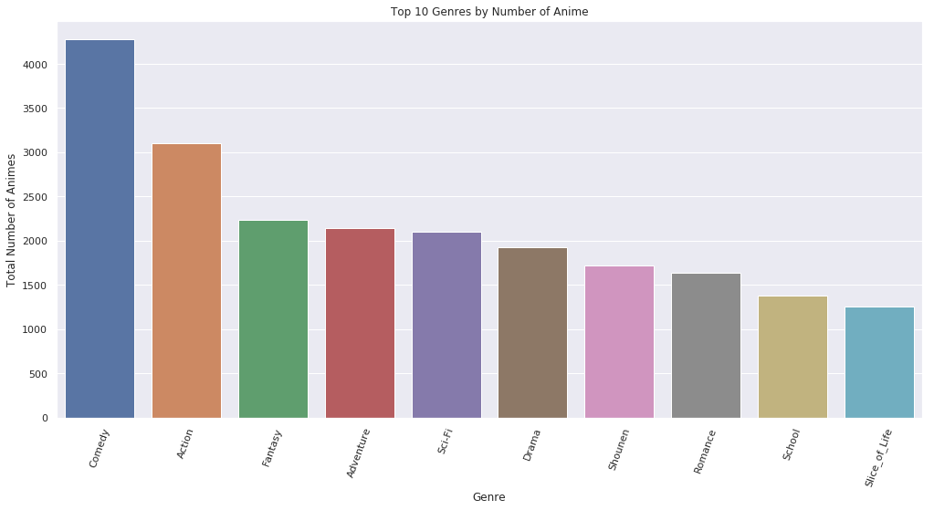

```python
%matplotlib inline
import matplotlib.pyplot as plt
import seaborn as sns
sns.set()


genre_num = {}
for i in genres:
    genre_num[i] = sum(genres[i]==1)

genres2 = pd.DataFrame.from_dict(data=genre_num, orient = 'index', columns = ['Number_of_Animes'])


plt.figure(figsize=(17,8))
plot = sns.barplot(genres2.sort_values('Number_of_Animes',ascending=False).head(10).index,
            genres2.sort_values('Number_of_Animes',ascending=False).head(10)['Number_of_Animes'])

plt.xticks(rotation=70)
plt.xlabel('Genre')
plt.ylabel('Total Number of Animes')
plt.title('Top 10 Genres by Number of Anime')
```

```python
(genre_num['Comedy'] / sum(genre_num.values()))
```

```
0.11746441721162829
```

```python
sum(genre_num.values())
```

```
36394
```

```python
genre_num
```

```
{'Action': 3099,
 'Adventure': 2146,
 'Cars': 54,
 'Comedy': 4275,
 'Dementia': 269,
 'Demons': 383,
 'Drama': 1921,
 'Ecchi': 705,
 'Fantasy': 2237,
 'Game': 264,
 'Harem': 372,
 'Hentai': 1231,
 'Historical': 653,
 'Horror': 369,
 'Josei': 87,
 'Kids': 623,
 'Magic': 857,
 'Martial_Arts': 297,
 'Mecha': 914,
 'Military': 483,
 'Music': 1032,
 'Mystery': 610,
 'Parody': 415,
 'Police': 203,
 'Psychological': 297,
 'Romance': 1640,
 'Samurai': 155,
 'School': 1380,
 'Sci-Fi': 2096,
 'Seinen': 698,
 'Shoujo': 596,
 'Shoujo_Ai': 71,
 'Shounen': 1714,
 'Shounen_Ai': 81,
 'Slice_of_Life': 1257,
 'Space': 398,
 'Sports': 504,
 'Super_Power': 496,
 'Supernatural': 1205,
 'Thriller': 102,
 'Vampire': 129,
 'Yaoi': 38,
 'Yuri': 38}
```

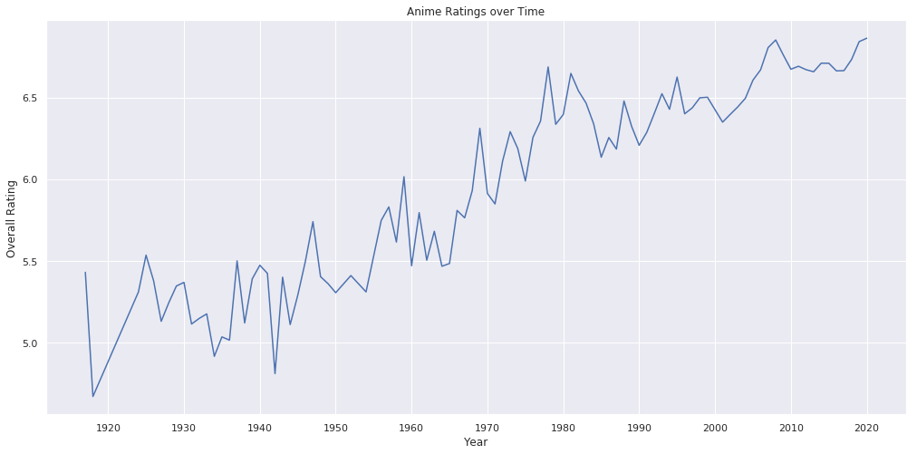

```python
anime['air_date'] = pd.to_datetime(anime['air_date'])
anime['year'] = anime['air_date'].dt.year

plt.figure(figsize=(17,8))
sns.lineplot(anime.year, anime.overall_rating, ci=None)
plt.xticks(ticks=range(1920,2021,10))
plt.xlabel('Year')
plt.ylabel('Overall Rating')
plt.title('Anime Ratings over Time')
```

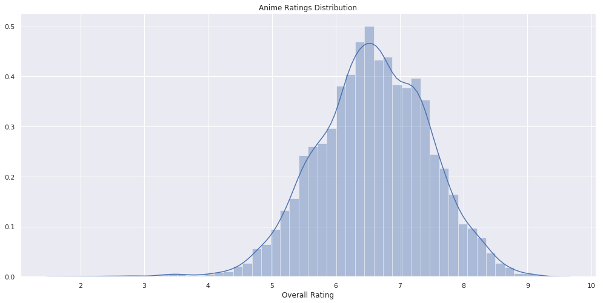

```python
plt.figure(figsize=(17,8))
sns.distplot(anime.overall_rating)
plt.xlabel('Overall Rating')
plt.title('Anime Ratings Distribution')
```

```python
print('Mean: ',anime['overall_rating'].mean())
print('Median', np.median(anime['overall_rating']))
print('Standard Deviation: ',anime['overall_rating'].std())
```

```
Mean:  6.582786899640005
Median 6.59
Standard Deviation:  0.8700039739161602
```

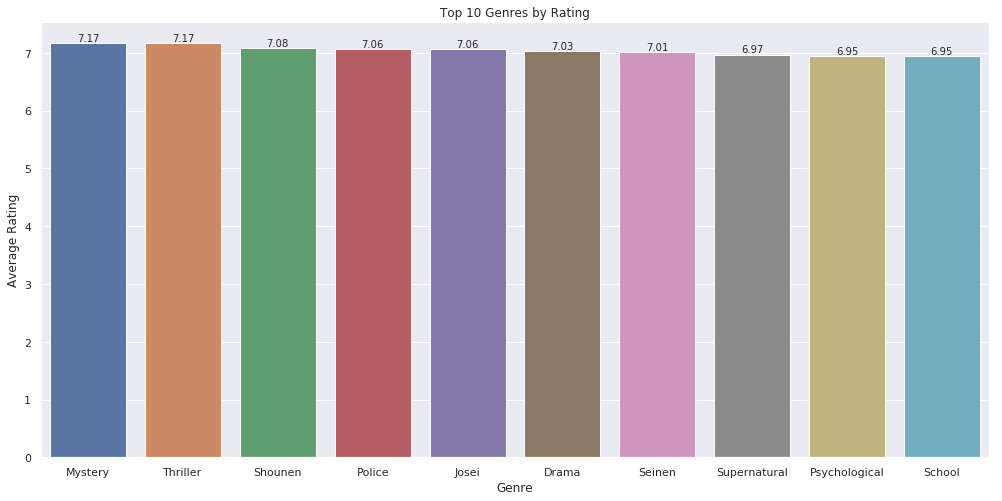

```python
genre_ratings = {}
for i in genres:
    genre_ratings[i] = round(np.mean(anime['overall_rating'][genres[i]==1]),2)

genres_ratings_df = pd.DataFrame.from_dict(data=genre_ratings, orient = 'index', columns = ['Mean_Rating'])

fig, ax = plt.subplots(figsize=(17,8))
plot = sns.barplot(genres_ratings_df.sort_values('Mean_Rating',ascending=False).head(10).index,
                   genres_ratings_df.sort_values('Mean_Rating',ascending=False).head(10)['Mean_Rating'])

plt.xlabel('Genre')
plt.ylabel('Average Rating')
plt.title('Top 10 Genres by Rating')
for i, val in enumerate(genres_ratings_df.sort_values('Mean_Rating',ascending=False).head(10)['Mean_Rating'].values):
    ax.text(i, val, float(val), horizontalalignment='center',
             verticalalignment='bottom', fontdict={'fontweight':300, 'size':10})
```

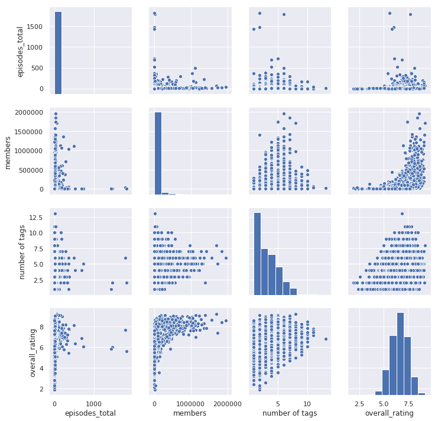

```python
sns.pairplot(anime[['episodes_total', 'members', 'number of tags', 'overall_rating']])
```

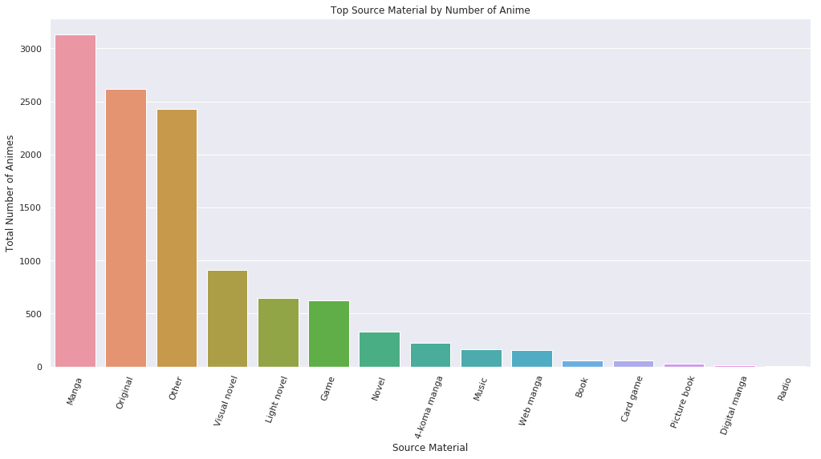

```python
plt.figure(figsize=(17,8))
sns.countplot(anime.source_material, order=anime.source_material.value_counts().index)
plt.xticks(rotation=70)
plt.xlabel('Source Material')
plt.ylabel('Total Number of Animes')
plt.title('Top Source Material by Number of Anime')
```

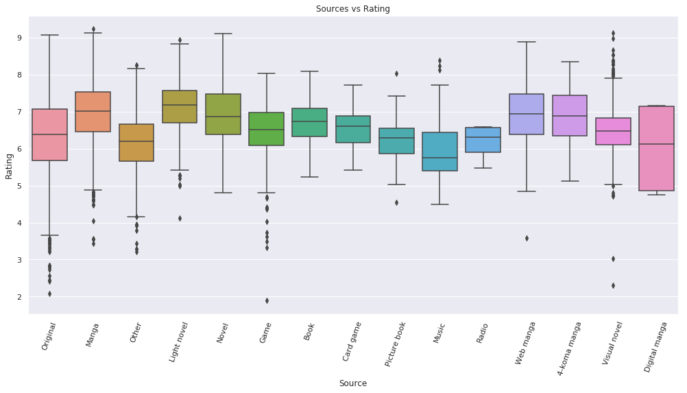

```python
plt.figure(figsize=(17,8))
sns.boxplot(anime.source_material, anime.overall_rating)
plt.xticks(rotation = 70)
plt.xlabel('Source')
plt.ylabel('Rating')
plt.title('Sources vs Rating')
```

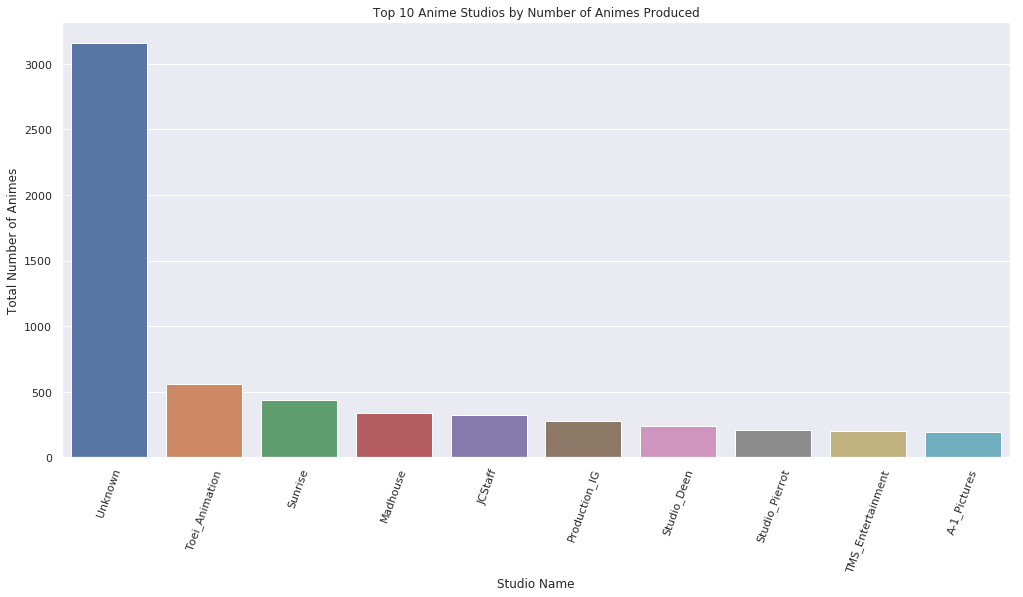

```python
plt.figure(figsize=(17,8))
sns.countplot(anime.studio_name, order=anime.studio_name.value_counts().iloc[:10].index)
plt.xticks(rotation = 70)
plt.xlabel('Studio Name')
plt.ylabel('Total Number of Animes')
plt.title('Top 10 Anime Studios by Number of Animes Produced')
```

```python
anime[['anime_name','overall_rating']].sort_values('overall_rating',ascending = False)[:20] #Top 20 anime
```

|  | anime_name | overall_rating |
| --- | --- | --- |
| 510 | Fullmetal Alchemist: Brotherhood | 9.23 |
| 14016 | Steins;Gate | 9.13 |
| 15428 | Gintama° | 9.12 |
| 871 | Hunter x Hunter (2011) | 9.12 |
| 12839 | Ginga Eiyuu Densetsu | 9.11 |
| 288 | Gintama' | 9.10 |
| 15616 | Shingeki no Kyojin Season 3 Part 2 | 9.08 |
| 12238 | Kimi no Na wa. | 9.07 |
| 343 | Gintama': Enchousen | 9.05 |
| 12615 | 3-gatsu no Lion 2nd Season | 9.03 |
| 4188 | Koe no Katachi | 9.02 |
| 342 | Gintama Movie 2: Kanketsu-hen - Yorozuya yo Ei... | 8.99 |
| 15441 | Gintama. | 8.99 |
| 51 | Gintama | 8.98 |
| 4130 | Clannad: After Story | 8.98 |
| 12616 | Owarimonogatari 2nd Season | 8.95 |
| 3605 | Haikyuu!!: Karasuno Koukou vs. Shiratorizawa G... | 8.95 |
| 163 | Code Geass: Hangyaku no Lelouch R2 | 8.92 |
| 594 | Mob Psycho 100 II | 8.89 |
| 4823 | Sen to Chihiro no Kamikakushi | 8.87 |

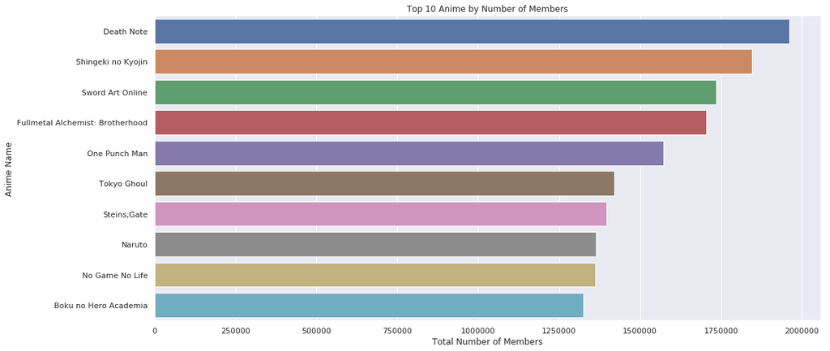

```python
members_anime = anime[['anime_name', 'members']].copy()

members_anime = members_anime.sort_values('members',ascending=False).reset_index()

plt.figure(figsize=(17,8))
sns.barplot(members_anime.members, members_anime.anime_name.head(10))
plt.ylabel('Anime Name')
plt.xlabel('Total Number of Members')
plt.title('Top 10 Anime by Number of Members')
```

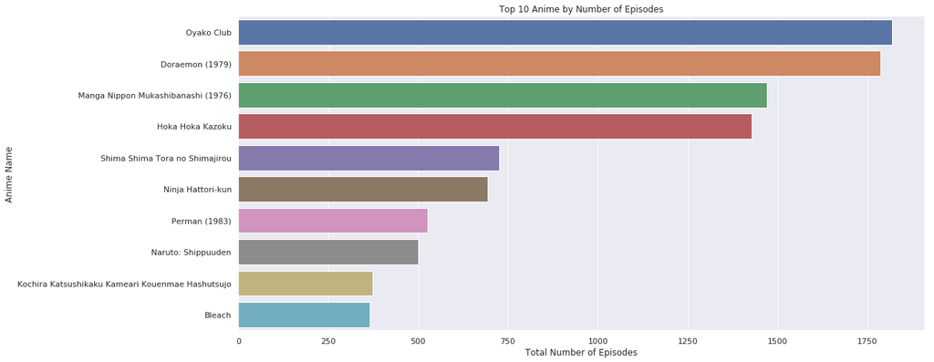

```python
eps_anime = anime[['anime_name', 'episodes_total']].copy()

eps_anime = eps_anime.sort_values('episodes_total',ascending=False).reset_index()

plt.figure(figsize=(17,8))
sns.barplot(eps_anime.episodes_total, eps_anime.anime_name.head(10))
plt.ylabel('Anime Name')
plt.xlabel('Total Number of Episodes')
plt.title('Top 10 Anime by Number of Episodes')
```

### K-Nearest Neighbors (KNN)

#### Regression

```python
animeX = anime[['anime_id', 'source_material', 'members', 'Action', 'Adventure', 'Cars', 'Comedy', 'Dementia',
       'Demons', 'Drama', 'Ecchi', 'Fantasy', 'Game', 'Harem', 'Hentai',
       'Historical', 'Horror', 'Josei', 'Kids', 'Magic', 'Martial_Arts',
       'Mecha', 'Military', 'Music', 'Mystery', 'Parody', 'Police',
       'Psychological', 'Romance', 'Samurai', 'School', 'Sci-Fi', 'Seinen',
       'Shoujo', 'Shoujo_Ai', 'Shounen', 'Shounen_Ai', 'Slice_of_Life',
       'Space', 'Sports', 'Super_Power', 'Supernatural', 'Thriller', 'Vampire',
       'Yaoi', 'Yuri']].copy()
animeX = pd.get_dummies(animeX)
animeY = anime['overall_rating'].copy()
```

```python
from sklearn.model_selection import train_test_split
X_train, X_test, y_train, y_test = train_test_split(animeX, animeY, test_size = 0.2, random_state = 0)
```

```python
from sklearn.preprocessing import StandardScaler
sc = StandardScaler()

X_train_scaled = sc.fit_transform(X_train)
X_test_scaled = sc.transform(X_test)
```

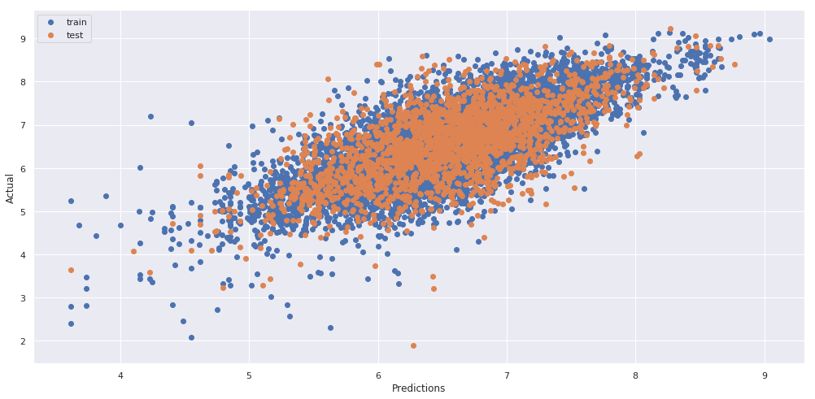

```python
from sklearn.neighbors import KNeighborsRegressor

knn = KNeighborsRegressor(n_neighbors=6)

knn.fit(X_train_scaled,y_train)

train_pred = knn.predict(X_train_scaled)
test_pred = knn.predict(X_test_scaled)


plt.figure(figsize=(17,8))
plt.scatter(train_pred, y_train, label='train')
plt.scatter(test_pred, y_test, label='test')
plt.xlabel('Predictions')
plt.ylabel('Actual')
plt.legend()
plt.show()
```

```python
print("KNN Regression model accuracy: {:.2f}%".format(knn.score(X_test_scaled, y_test) * 100))
```

```
KNN Regression model accuracy: 43.17%
```

#### Classification

```python
animeX = anime[['anime_id', 'source_material', 'members', 'Action', 'Adventure', 'Cars', 'Comedy', 'Dementia',
       'Demons', 'Drama', 'Ecchi', 'Fantasy', 'Game', 'Harem', 'Hentai',
       'Historical', 'Horror', 'Josei', 'Kids', 'Magic', 'Martial_Arts',
       'Mecha', 'Military', 'Music', 'Mystery', 'Parody', 'Police',
       'Psychological', 'Romance', 'Samurai', 'School', 'Sci-Fi', 'Seinen',
       'Shoujo', 'Shoujo_Ai', 'Shounen', 'Shounen_Ai', 'Slice_of_Life',
       'Space', 'Sports', 'Super_Power', 'Supernatural', 'Thriller', 'Vampire',
       'Yaoi', 'Yuri']].copy()
animeX = pd.get_dummies(animeX)
animeY = anime['overall_rating'].apply(np.floor).copy()
```

```python
from sklearn.model_selection import train_test_split
X_train, X_test, y_train, y_test = train_test_split(animeX, animeY, test_size = 0.2, random_state = 0)
```

```python
from sklearn.preprocessing import StandardScaler
sc = StandardScaler()

X_train_scaled = sc.fit_transform(X_train)
X_test_scaled = sc.transform(X_test)
```

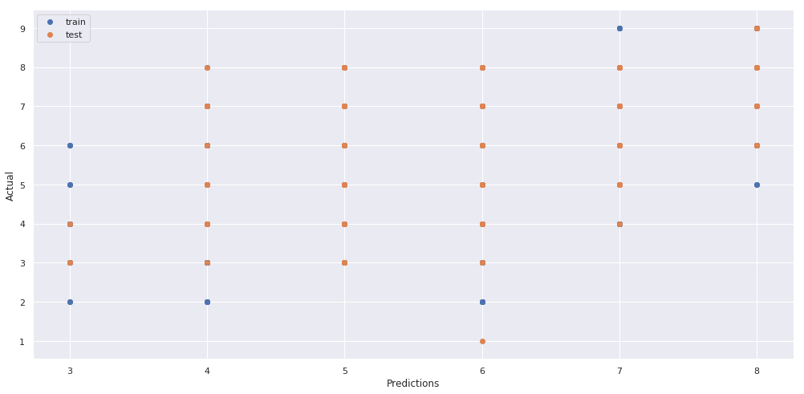

```python
from sklearn.neighbors import KNeighborsClassifier

knn = KNeighborsClassifier(n_neighbors=10)

knn.fit(X_train_scaled,y_train)

train_pred = knn.predict(X_train_scaled)
test_pred = knn.predict(X_test_scaled)

plt.figure(figsize=(17,8))
plt.scatter(train_pred, y_train, label='train')
plt.scatter(test_pred, y_test, label='test')
plt.xlabel('Predictions')
plt.ylabel('Actual')
plt.legend()
plt.show()
```

```python
print("KNN Classifcation model accuracy: {:.2f}%".format(knn.score(X_test_scaled, y_test) * 100))
```

```
KNN Classifcation model accuracy: 53.20%
```

I ran both a regression and classifcation KNN model to compare accuracy of the two approaches. Classification proved to be a more accuate model by about 10%. I believe due to the 'Curse of Dimensionality', my models' accuracy are not as high as they could be. To increase accuracy, more data would need to be added to this dataset to offset the large number of features.